# Gov 50 Final Project: The Effects of Home Ice Advantage in the NHL

Thomas J. Mete

### Section One: Introduction

In all major sports leagues, “home advantage” has emerged as an influential aspect regardless of the sport. It has left players, coaches, and insiders convinced the “home advantage” teams bear for fifty percent of their regular season games, may be enough to tilt the field in their favor when a game is underway. The notion of performing better at home is engrained in the culture of professional sports, serving as a coveted prize of teams that finish the season at the top of the standings when playoffs ensue. In a sports world that has become fiercely competitive on the field, off the field the rise of online gambling has altered the odds beating landscape. Viewers at home, turned recreational sports gamblers, like players are turning to “home advantage” as a potential prospect to help rise above the rest. Whether it be playing a game in front of a boisterous home crowd, the familiarity and comfort that comes with playing in a familiar stadium, or some intangible factor, team’s have been left with the opinion that their local environment, due in fact, provide a crucial boost when it is all on the line.

Over the course of this project, I will empirically explore the effects of “home advantage” in the National Hockey League (NHL). I plan on exploring whether the location of the hockey game has an effect on the number of goals scored by a team with goals scored being a measurable and significant predictor of game outcomes.The central research question of this project is whether playing at home increases the number of goals scored by the team? I hypothesize that playing at home does indeed boost the goals scored of the home team, as unlike most other sports, in the NHL there is a built-in home advantage. This research question will be mainly tested and observed through the Boston Bruins.

During a stoppage in play, the final line change is given to the home team after the visiting team sends its players out onto the ice. This rule gives the coach of the home team more control and allows him to strategically deploy his players, either in a defensive posture or in an effort to create more offense.

Exploring this research question — through the Boston Bruins — is of importance as it aims to empirically confirm or disprove a long standing belief with the NHL community that playing at home provides a boost. This understanding is crucial during playoff hockey games when teams are in a grueling battle to emerge as the league’s leading contenders and vie for the title of Stanley Cup Champions.

### Section Two: Data Section

#### Read in the Data Set

```r
library(dbplyr)
library(tidyverse)
```

```r
# Read in the two data sets
latest <- read.csv("nhl_elo_latest.csv")
historical <- read.csv("nhl_elo.csv")

## Merge Datasets
total <- rbind(latest, historical)

## See the Datasets
knitr::kable(head(latest))
```

| season | date | playoff | neutral | status | ot | home_team | away_team | home_team_abbr | away_team_abbr | home_team_pregame_rating | away_team_pregame_rating | home_team_winprob | away_team_winprob | overtime_prob | home_team_expected_points | away_team_expected_points | home_team_score | away_team_score | home_team_postgame_rating | away_team_postgame_rating | game_quality_rating | game_importance_rating | game_overall_rating |
| --- | --- | --- | --- | --- | --- | --- | --- | --- | --- | --- | --- | --- | --- | --- | --- | --- | --- | --- | --- | --- | --- | --- | --- |
| 2023 | 2022-10-07 | 0 | 1 | post |  | Nashville Predators | San Jose Sharks | NSH | SJS | 1506.268 | 1450.241 | 0.5799375 | 0.4200625 | 0.2343447 | 1.258314 | 0.9760303 | 4 | 1 | 1510.044 | 1446.464 | 15 | 41 | 28 |
| 2023 | 2022-10-08 | 0 | 1 | post |  | San Jose Sharks | Nashville Predators | SJS | NSH | 1446.464 | 1510.044 | 0.4095091 | 0.5904909 | 0.2330533 | 0.956634 | 1.2764193 | 2 | 3 | 1444.546 | 1511.962 | 15 | 43 | 29 |
| 2023 | 2022-10-11 | 0 | 0 | post |  | New York Rangers | Tampa Bay Lightning | NYR | TBL | 1550.569 | 1571.159 | 0.5422235 | 0.4577765 | 0.2389354 | 1.193826 | 1.0451095 | 3 | 1 | 1554.003 | 1567.725 | 97 | 24 | 60 |
| 2023 | 2022-10-11 | 0 | 0 | post |  | Los Angeles Kings | Vegas Golden Knights | LAK | VEG | 1501.129 | 1528.454 | 0.5325853 | 0.4674147 | 0.2401068 | 1.177400 | 1.0627068 | 3 | 4 | 1498.529 | 1531.055 | 60 | 77 | 68 |
| 2023 | 2022-10-12 | 0 | 0 | post |  | Carolina Hurricanes | Columbus Blue Jackets | CAR | CBJ | 1554.744 | 1474.220 | 0.6794736 | 0.3205264 | 0.2218241 | 1.430048 | 0.7917764 | 4 | 1 | 1557.527 | 1471.437 | 58 | 36 | 47 |
| 2023 | 2022-10-12 | 0 | 0 | post |  | Washington Capitals | Boston Bruins | WSH | BOS | 1526.149 | 1547.169 | 0.5416098 | 0.4583902 | 0.2390100 | 1.192780 | 1.0462305 | 2 | 5 | 1521.075 | 1552.243 | 84 | 54 | 69 |

```r
knitr::kable(head(historical))
```

| season | date | playoff | neutral | status | ot | home_team | away_team | home_team_abbr | away_team_abbr | home_team_pregame_rating | away_team_pregame_rating | home_team_winprob | away_team_winprob | overtime_prob | home_team_expected_points | away_team_expected_points | home_team_score | away_team_score | home_team_postgame_rating | away_team_postgame_rating | game_quality_rating | game_importance_rating | game_overall_rating |
| --- | --- | --- | --- | --- | --- | --- | --- | --- | --- | --- | --- | --- | --- | --- | --- | --- | --- | --- | --- | --- | --- | --- | --- |
| 1918 | 1917-12-19 | 0 | 0 | post |  | Ottawa Senators | Montreal Canadiens | OTS | MTL | 1380.000 | 1380.000 | 0.5714631 | 0.4285369 | 0.2348521 | 1.243569 | 0.9912831 | 4 | 7 | 1374.590 | 1385.410 | 0 | NA | NA |
| 1918 | 1917-12-19 | 0 | 0 | post |  | Montreal Wanderers | Toronto Maple Leafs | MTW | TOR | 1380.000 | 1380.000 | 0.5714631 | 0.4285369 | 0.2348521 | 1.243569 | 0.9912831 | 10 | 9 | 1382.020 | 1377.980 | 0 | NA | NA |
| 1918 | 1917-12-21 | 0 | 0 | post |  | Montreal Wanderers | Montreal Canadiens | MTW | MTL | 1382.020 | 1385.410 | 0.5666778 | 0.4333222 | 0.2354509 | 1.235382 | 1.0000693 | 2 | 11 | 1374.109 | 1393.321 | 0 | NA | NA |
| 1918 | 1917-12-21 | 0 | 0 | post |  | Toronto Maple Leafs | Ottawa Senators | TOR | OTS | 1377.980 | 1374.590 | 0.5762352 | 0.4237648 | 0.2342543 | 1.251739 | 0.9825153 | 11 | 4 | 1383.198 | 1369.372 | 0 | NA | NA |
| 1918 | 1917-12-26 | 0 | 0 | post |  | Toronto Maple Leafs | Montreal Canadiens | TOR | MTL | 1383.198 | 1393.321 | 0.5571372 | 0.4428628 | 0.2366435 | 1.219075 | 1.0175685 | 7 | 5 | 1386.504 | 1390.016 | 0 | NA | NA |
| 1918 | 1917-12-26 | 0 | 0 | post |  | Montreal Wanderers | Ottawa Senators | MTW | OTS | 1374.109 | 1369.372 | 0.5781279 | 0.4218721 | 0.2340170 | 1.254981 | 0.9790360 | 3 | 6 | 1368.623 | 1374.858 | 0 | NA | NA |

##### Verify that the merge of datasets was successful.

```r
total |>
  filter(season == 1918)

total |>
  filter(season == 2023)
```

##### Create a new variable to outline if a game concluded in overtime, multiple overtimes, or a shootout.

```r
## Make Overtime variable numeric
total <- total |>
  mutate(
    overtime = if_else(ot == "OT", 1, 0),
    shootout = if_else(ot == "SO", 1, 0)
  )
```

This project merges two data sets to analyze the effects of home ice advantage on goals scored over the entirety of the NHL. The first dataset contains historical NHL data beginning with the 1917-1918 NHL season and ending with the 2021-2022 NHL season. The second data set is the latest NHL data from the 2022-2023 NHL season. These datasets recorded every NHL game played across all seasons, the variables reported that are of interest to this project are home team name, away team name, home team score, away team score, whether the game was in the playoffs, if the game ended in overtime or a shootout. This data set contains data that is a cross-sectional research design. This is a cross-sectional research design as it collects data on the NHL games from a certain point in time and is strictly observational thus there are no interventions, manipulations or follow ups to the one time assessment.

These two data sets did not provide team specific variables so I have created the independent and dependent variables for the Boston Bruins, along with other teams that will be discussed further in the project.

```r
bos_data <- total |>
  filter(home_team_abbr == "BOS" | away_team_abbr == "BOS") |>
  mutate(bos_location = if_else(home_team_abbr == "BOS", "Home", "Away"),
         bos_score = if_else(bos_location == "Away", away_team_score, home_team_score))
```

Here we have created a data set that has variables pertaining to the Boston Bruins. Below are the extracted columns of interest in the preliminary research of this project the independent and dependent variable.

```r
bos_ind_dep <- bos_data[, c("bos_score", "bos_location")]
knitr::kable(head(bos_ind_dep))
```

| bos_score | bos_location |
| --- | --- |
| 5 | Away |
| 6 | Home |
| 5 | Home |
| 5 | Away |
| 2 | Home |
| 4 | Home |

A brief visualization of the independent and dependent variables can be found below as a boxplot. This provides us with a graphical representations of these two variables and provides a summary of the key characteristics of the data, allowing for easy identification of central tendency, dispersion, and the presence of outliers. A key reason I selected this method was it is useful to compare a catogrical (bos_location) and numerical (bos_score) variable.

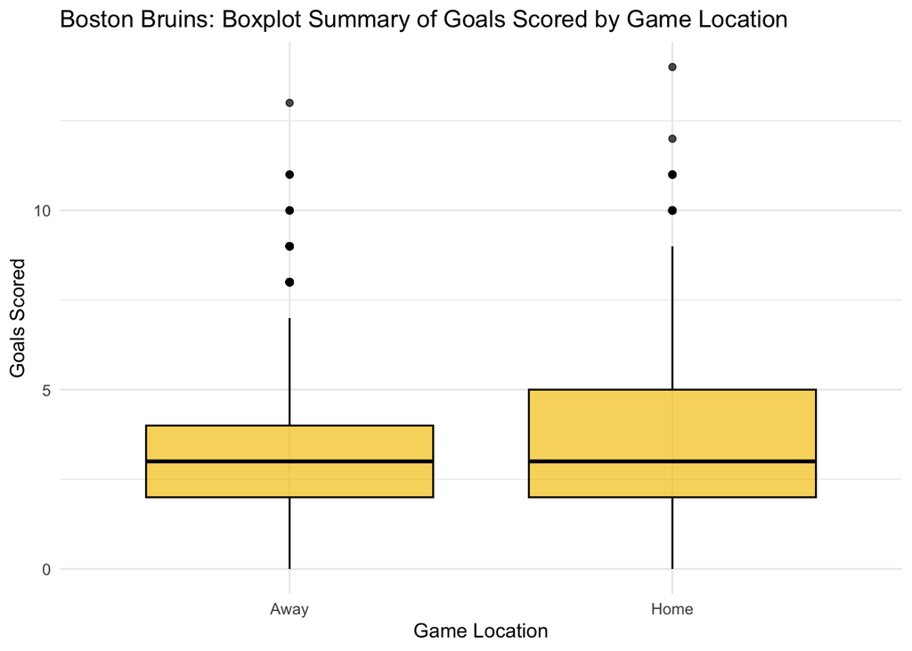

```r
bos_ind_dep_vis <- ggplot(bos_ind_dep, aes(x = bos_location, y = bos_score)) +
  geom_boxplot(fill = "#F5C710", color = "black", alpha = 0.7) +
  labs(title = "Boston Bruins: Boxplot Summary of Goals Scored by Game Location",
       x = "Game Location",
       y = "Goals Scored") +
  theme_minimal()
bos_ind_dep_vis
```

### Section Three: Results (Plots, Regressions, and Descriptions)

Over the course of this section of the project I will explore the effects of the Boston Bruins goals scored from home ice advantage through bootstrapping, a main regression of interest, and a multi-variable regression. After we will examine a high fan engagement market and low fan engagement market (something that is not measured through a variable) to examine if there is at least some correlation in home ice advantage with fan engagement, we will approach this using bootstrapping.

For the Boston Bruins portion of the results, our null hypothesis is that there is no effect on goals scored from home ice advantage. Our alternative hypothesis is that there is a positive effect on goals scored from home ice advantage. Using these our original research question and hypothesis in the introduction would be proven to be true if we reject the null.

##### ATE of Playing at Home on Goals Scored for the Boston Bruins

```r
bos_ate <- bos_data |>
  group_by(bos_location) |>
  summarise(bos_score_mean = mean(bos_score)) |>
  pivot_wider(names_from = bos_location, values_from = bos_score_mean) |>
  mutate(ATE = `Home` - `Away`)
bos_ate
```

```
## # A tibble: 1 × 3
##    Away  Home   ATE
##   <dbl> <dbl> <dbl>
## 1  2.91  3.43 0.517
```

```r
knitr::kable(
  bos_ate,
  col.names = c("Away", "Home", "ATE of Home Ice"), caption = "Boston Bruins: Number Goals Scored",
  digits = 2)
```

Boston Bruins: Number Goals Scored

| Away | Home | ATE of Home Ice |
| --- | --- | --- |
| 2.91 | 3.43 | 0.52 |

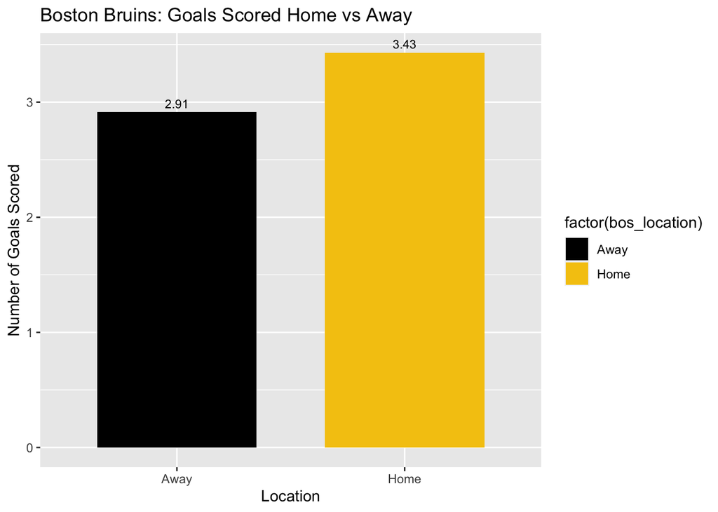

```r
## Visualization Comparing Number of Goals Boston Scores at Home versus Away
plot_visb <- bos_data |>
  group_by(bos_location) |>
  summarise(bos_score_mean = mean(bos_score)) |>
  ggplot(aes(x = bos_location, y = bos_score_mean, fill = factor(bos_location))) +
  geom_col(width = 0.7) +
  labs(title = "Boston Bruins: Goals Scored Home vs Away",
       x = "Location",
       y = "Number of Goals Scored") +
  scale_fill_manual(values = c("Home" = "#F5C710", "Away" = "black")) +
  geom_text(aes(label = round(bos_score_mean, 2)),
            position = position_dodge(width = 0.7),
            vjust = -0.5, color = "black", size = 3)
plot_visb
```

##### Interpretation of the Average Treatment Effect

The estimated effect of the Boston Bruins playing an NHL game at home versus playing an NHL game away is an increase in the Boston Bruins number of goals scored by 0.52.

This average treatment effect shows that there are more goal scored when the Boston Bruins plat at home which is in line with our original hypothesis, we will bootstrap and examine confidence intervals to further interperate the relationship and validity of these results.

##### Bootstrapping Examining the Effects of Goals Scored When Playing at Home for the Boston Bruins

```r
#Let's Try Bootstrapping
library(infer)

bos_boots <- bos_data |>
  rep_slice_sample(prop = 1, replace = TRUE, reps = 1000) |>
  group_by(replicate, bos_location) |>
  summarise(bos_score_mean = mean(bos_score)) |>
  pivot_wider(names_from = bos_location, values_from = bos_score_mean) |>
  mutate(ATE = `Home` - `Away`) |>
  select(replicate, ATE)
```

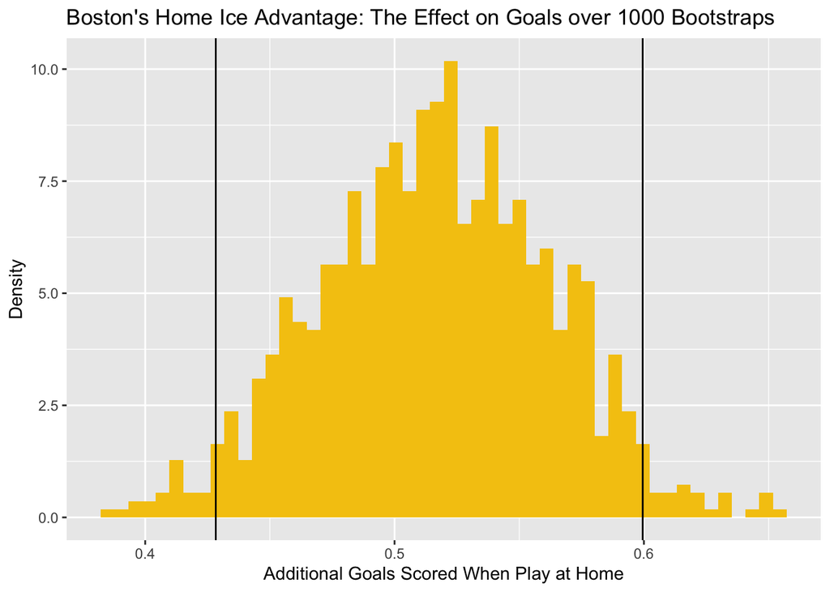

```r
bos_ci_95 <- bos_boots |>
  get_confidence_interval(level = 0.95, type = "percentile")

bos_boots_plot <- bos_boots |>
  ggplot(mapping = aes(x = ATE)) +
  geom_histogram(aes(y = after_stat(density)), binwidth = 0.0055, fill = "#F5C710") +
  geom_vline(xintercept = unlist(bos_ci_95)) +
  labs(y = "Density", x = "Additional Goals Scored When Play at Home") +
  ggtitle("Boston's Home Ice Advantage: The Effect on Goals over 1000 Bootstraps")
bos_boots_plot
```

```r
knitr::kable(
  bos_ci_95,
  col.names = c("Lower Confidence Interval", "Upper Confidence Interval"), caption = "Boston Bruins: Confidence Interval at 95%",
  digits = 2)
```

Boston Bruins: Confidence Interval at 95%

| Lower Confidence Interval | Upper Confidence Interval |
| --- | --- |
| 0.43 | 0.6 |

##### Interpretation of the Confidence Interval

The confidence interval for the Boston Bruins is 0.43 to 0.60, which does not include 0. This means that no difference between the number of goals scored at home or away is not a plausible value of the true population parameter, at least at the 95% confidence level.

This confidence interval of 0.43 to 0.60 provides a range of plausible values in this case meaning the true difference in the number of goals scored at home versus away for the Boston Bruins. This also leads us to the conclusion that we have a statistically significant finding as a 95% confidence interval tells us that if we were to replicate this experiment, 95% of the results would exclude zero.

#### Looking at the Boston Bruins we will run a regression of the number of goals scored (`bos_score`) as the dependent variable, `bos_location` as the main independent variable. This is a two variable regression.

My primary independent variable of interest was the boston location variable, which shows if the game was played at home or away. The following regression table displays the details for a regression equation involving only that variable.

```r
library(broom)

##Regular Regression

fit_bos <- lm(bos_score ~ bos_location, data = bos_data)

summary(fit_bos)
```

```
##
## Call:
## lm(formula = bos_score ~ bos_location, data = bos_data)
##
## Residuals:
##     Min      1Q  Median      3Q     Max
## -3.4296 -1.4296 -0.4296  1.0873 10.5704
##
## Coefficients:
##                  Estimate Std. Error t value Pr(>|t|)
## (Intercept)       2.91273    0.03137   92.84   <2e-16 ***
## bos_locationHome  0.51685    0.04429   11.67   <2e-16 ***
## ---
## Signif. codes:  0 '***' 0.001 '**' 0.01 '*' 0.05 '.' 0.1 ' ' 1
##
## Residual standard error: 1.926 on 7567 degrees of freedom
## Multiple R-squared:  0.01768,    Adjusted R-squared:  0.01755
## F-statistic: 136.2 on 1 and 7567 DF,  p-value: < 2.2e-16
```

```r
var_labels_l <- c(
"(Intercept)" = "Intercept",
"bos_locationHome" = "Home Ice Advantage"
)

modelsummary::modelsummary(fit_bos,
                           statistic = c("s.e. = {std.error}",
                                         "p = {p.value}"),
                           coef_map = var_labels_l,
                           gof_map = c("nobs", "r.squared", "adj.r.squared"))
```

|  | (1) |
| --- | --- |
| Intercept | 2.913 |
|  | s.e. = 0.031 |
|  | p = <0.001 |
| Home Ice Advantage | 0.517 |
|  | s.e. = 0.044 |
|  | p = <0.001 |
| Num.Obs. | 7569 |
| R2 | 0.018 |
| R2 Adj. | 0.018 |

##### Interpretation of the Regression

The regression table above displays an intercept of the line of 2.913, meaning that, in games that are not played at home for the Boston Bruins they score 2.913 goals. The coefficient associated with bos_location is 0.517, which also represents the slope. This can be interpreted to mean that when a game is played in Boston, there is a 0.517 increase in the number of goals scored by the Boston Bruins. This number has a p-value of less than 0.001, which is statistically significant with an alpha of 0.05. Given that the p-value is less than the alpha of 0.05 we can reject the null hypothesis that there is no effect on goals scored from home ice advantage.

#### Looking at the Boston Bruins we will run a multi variable regression of the number of goals scored (`bos_score`) as the dependent variable, `bos_location` as the main independent variable and the following other control/independent variables playoff game (`playoff`) and game went to overtime (`ot`).

```r
##Multi Variable Regression

fit_bos_multi <- lm(bos_score ~ bos_location + playoff + overtime + shootout, data = bos_data)

summary(fit_bos_multi)
```

```
##
## Call:
## lm(formula = bos_score ~ bos_location + playoff + overtime +
##     shootout, data = bos_data)
##
## Residuals:
##     Min      1Q  Median      3Q     Max
## -3.5203 -1.5203 -0.0046  0.9968 10.4797
##
## Coefficients:
##                  Estimate Std. Error t value Pr(>|t|)
## (Intercept)       3.00461    0.03307  90.858  < 2e-16 ***
## bos_locationHome  0.51571    0.04408  11.700  < 2e-16 ***
## playoff          -0.26441    0.07646  -3.458 0.000547 ***
## overtime         -0.51716    0.07081  -7.304 3.08e-13 ***
## shootout         -0.46485    0.14995  -3.100 0.001942 **
## ---
## Signif. codes:  0 '***' 0.001 '**' 0.01 '*' 0.05 '.' 0.1 ' ' 1
##
## Residual standard error: 1.917 on 7564 degrees of freedom
## Multiple R-squared:  0.02736,    Adjusted R-squared:  0.02685
## F-statistic:  53.2 on 4 and 7564 DF,  p-value: < 2.2e-16
```

```r
var_labels <- c(
"(Intercept)" = "Intercept",
"bos_locationHome" = "Home Ice Advantage",
"playoff" = "Playoff Game",
"overtime" = "Game ends in Overtime",
"shootout" = "Game ends in Shootout"
)

modelsummary::modelsummary(fit_bos_multi,
                           statistic = c("s.e. = {std.error}",
                                         "p = {p.value}"),
                           coef_map = var_labels,
                           gof_map = c("nobs", "r.squared", "adj.r.squared"))
```

|  | (1) |
| --- | --- |
| Intercept | 3.005 |
|  | s.e. = 0.033 |
|  | p = <0.001 |
| Home Ice Advantage | 0.516 |
|  | s.e. = 0.044 |
|  | p = <0.001 |
| Playoff Game | −0.264 |
|  | s.e. = 0.076 |
|  | p = <0.001 |
| Game ends in Overtime | −0.517 |
|  | s.e. = 0.071 |
|  | p = <0.001 |
| Game ends in Shootout | −0.465 |
|  | s.e. = 0.150 |
|  | p = 0.002 |
| Num.Obs. | 7569 |
| R2 | 0.027 |
| R2 Adj. | 0.027 |

##### Interpretation of the Multi Variable Regression

In the table above, the intercept is 3.005, which implies that when all variables are controlled for meaning it is not a home game, not a playoff game, and the game does not end in overtime or a shootout there are 3.005 goals scored by the Boston Bruins.

We can observe that Home Ice Advantage variable has a coefficient of 0.516, which implies that when the Boston Bruins play at home they score 0.516 more goals, holding all other variable equal.

Of our other control independent variabes we observe that there are negative effects on goals scored. All of the coefficients in this table had p-values p = <0.001 which means that using a 95% confidence interval through an aplha level of 0.05, the results are highly statistical significance. However, when observing if a game ends in a shootout the p-value is p = 0.002, this is still below the aplha level of 0.05 implying the result is statisticaly significant but it is not as strong as the other observations in this regression.

When a game is played in the playoffs there is a negative effect of 0.264 goals scored on the Boston Bruins, when the game ends in overtime there is a negative effect of 0.517 goals scored on the Boston Bruins, when a games ends in a shootout there is a negative effect on goals scored of 0.465.

Overall, we will reject the null as there is a plausible effect on goals scored when the Boston Bruins play at home. However the number of goals scored when playing at home is strongest during a regular season game that concludes in regulation as we observed negative effects on goals scored for games in the playoffs and those that end in overtime or a shootout.

#### Exploring Fan Engagement

We will now move to exploring fan engagement another potential variable that could have been controlled for or could be impacting the relationship between the number of goals scored and home ice advantage. Fan engagement is not a variable measured in the data sets but I have selected the Montrèal Canadiens as a high fan engagement team and the Florida Panthers as a low fan engagement team. These teams were chose by looking at attendance of NHL games and qualitative research on NHL fanbases. We will examine how does fan engagement effects the number of goals scored when playing at home by simply comparing and analyzing the differences between the two teams that have different fan markets. I hypothesize that we will observe a greater effect on goals scored when a team plays at home if they have high fan engagement.

```r
#Montréal Canadiens
#Filter to Only Montréal, Make Variable for if MTL Home or Away and Variable for MTL Goals
mtl_data <- total |>
  filter(home_team_abbr == "MTL" | away_team_abbr == "MTL") |>
  mutate(mtl_location = if_else(home_team_abbr == "MTL", "Home", "Away"),
         mtl_score = if_else(mtl_location == "Away", away_team_score, home_team_score))

#Find ATE of Playing at Home on Goals Scored
mtl_ate <- mtl_data |>
  group_by(mtl_location) |>
  summarise(mtl_score_mean = mean(mtl_score)) |>
  pivot_wider(names_from = mtl_location, values_from = mtl_score_mean) |>
  mutate(ATE = `Home` - `Away`)
mtl_ate
```

```
## # A tibble: 1 × 3
##    Away  Home   ATE
##   <dbl> <dbl> <dbl>
## 1  2.83  3.51 0.678
```

```r
## Visualization Comparing Number of Goals Montrèal Scores at Home versus Away
plot_vism <- mtl_data |>
  group_by(mtl_location) |>
  summarise(mtl_score_mean = mean(mtl_score)) |>
  ggplot(aes(x = mtl_location, y = mtl_score_mean, fill = factor(mtl_location))) +
  geom_col(width = 0.7) +
  labs(title = "Montrèal Canadiens",
       x = "Location",
       y = "Number of Goals Scored") +
  scale_fill_manual(values = c("Home" = "#DF5365", "Away" = "blue")) +
  geom_text(aes(label = round(mtl_score_mean, 2)),
            position = position_dodge(width = 0.7),
            vjust = -0.5, color = "black", size = 3)

#Florida Panthers
#Filter to Only Florida, Make Variable for if FLA Home or Away and Variable for FLA Goals
fla_data <- total |>
  filter(home_team_abbr == "FLA" | away_team_abbr == "FLA") |>
  mutate(fla_location = if_else(home_team_abbr == "FLA", "Home", "Away"),
         fla_score = if_else(fla_location == "Away", away_team_score, home_team_score))

#Find ATE of Playing at Home on Goals Scored
fla_ate <- fla_data |>
  group_by(fla_location) |>
  summarise(fla_score_mean = mean(fla_score)) |>
  pivot_wider(names_from = fla_location, values_from = fla_score_mean) |>
  mutate(ATE = `Home` - `Away`)
fla_ate
```

```
## # A tibble: 1 × 3
##    Away  Home   ATE
##   <dbl> <dbl> <dbl>
## 1  2.64  2.94 0.303
```

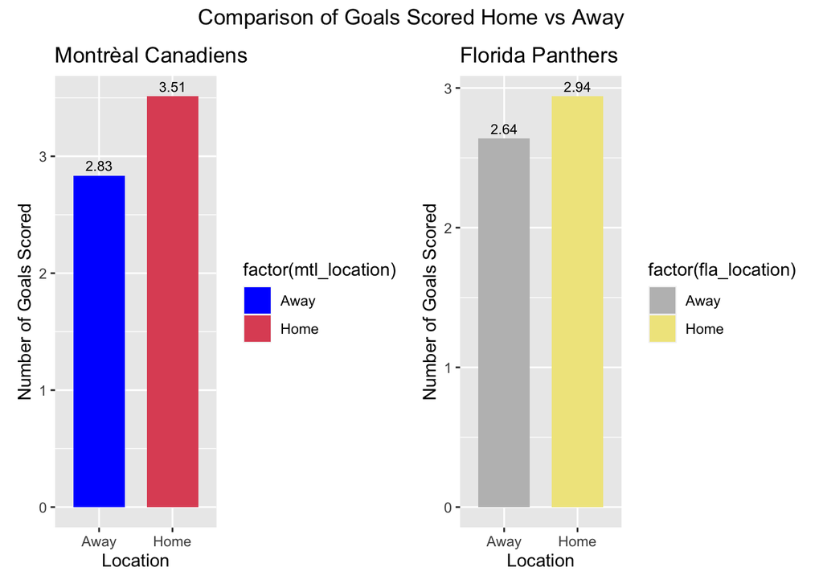

```r
## Visualization Comparing Number of Goals Florida Scores at Home versus Away
plot_visf <- fla_data |>
  group_by(fla_location) |>
  summarise(fla_score_mean = mean(fla_score)) |>
  ggplot(aes(x = fla_location, y = fla_score_mean, fill = factor(fla_location))) +
  geom_col(width = 0.7) +
  labs(title = "Florida Panthers",
       x = "Location",
       y = "Number of Goals Scored") +
  scale_fill_manual(values = c("Home" = "#F0E68C", "Away" = "grey")) +
  geom_text(aes(label = round(fla_score_mean, 2)),
            position = position_dodge(width = 0.7),
            vjust = -0.5, color = "black", size = 3)

# Combine Plots
library(patchwork)
combined_plot1 <- plot_vism + plot_visf +
  plot_layout(ncol = 2) +
  plot_annotation(title = "Comparison of Goals Scored Home vs Away",
                  theme = theme(plot.title = element_text(hjust = 0.5)))
combined_plot1
```

```r
# Combine the ATE table
library(kableExtra)
combined_ate <- cbind(fla_ate, mtl_ate) |>
  kbl(col.names = c("Away (FLA)", "Home (FLA)", "ATE of Home Ice (FLA)",
                    "Away (MTL)", "Home (MTL)", "ATE of Home Ice (MTL)"),
      caption = "Florida Panthers and Montréal Canadiens: Comparison of Number of Goals Scored",
      digits = 2) |>
  kable_styling()
combined_ate
```

Florida Panthers and Montréal Canadiens: Comparison of Number of Goals Scored

| Away (FLA) | Home (FLA) | ATE of Home Ice (FLA) | Away (MTL) | Home (MTL) | ATE of Home Ice (MTL) |
| --- | --- | --- | --- | --- | --- |
| 2.64 | 2.94 | 0.3 | 2.83 | 3.51 | 0.68 |

##### Brief Interpretation of the Average Treatment Effect

The estimated effect of the Montrèal Canadiens playing an NHL game at home versus playing an NHL game away is an increase in the Montrèal Canadiens number of goals scored by 0.68.

The estimated effect of the Florida Panthers playing an NHL game at home versus playing an NHL game away is an increase in the Florida Panthers number of goals scored by 0.30.

```r
#Let's Try Bootstrapping Montrèal
library(infer)
mtl_boots <- mtl_data |>
  rep_slice_sample(prop = 1, replace = TRUE, reps = 1000) |>
  group_by(replicate, mtl_location) |>
  summarise(mtl_score_mean = mean(mtl_score)) |>
  pivot_wider(names_from = mtl_location, values_from = mtl_score_mean) |>
  mutate(ATE = `Home` - `Away`) |>
  select(replicate, ATE)
```

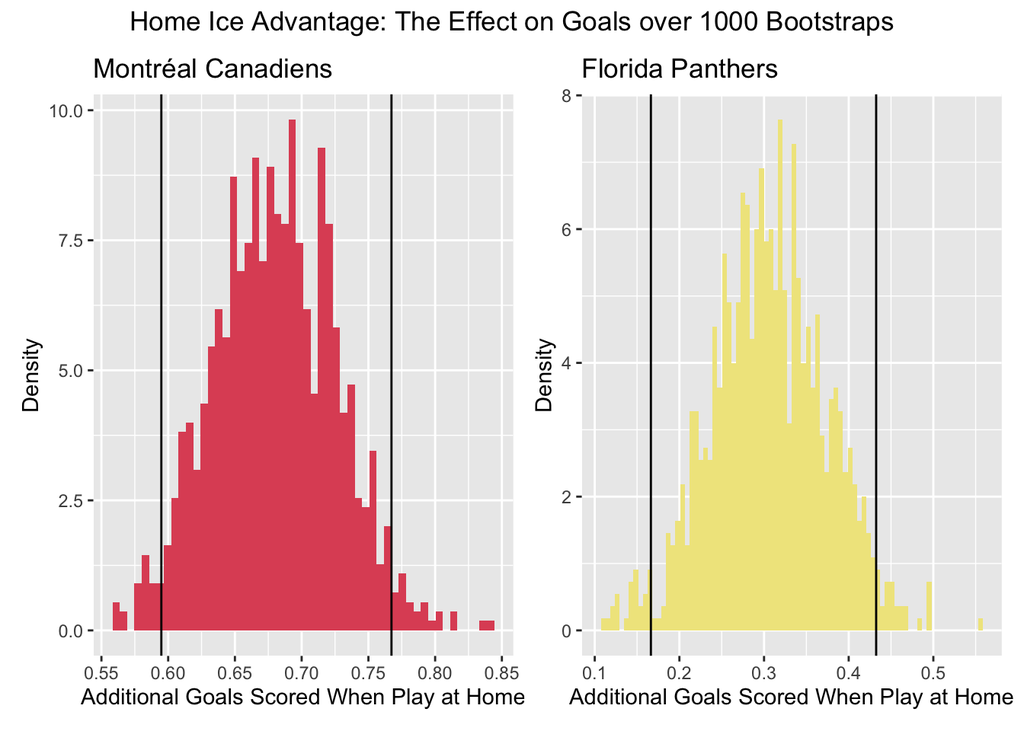

```r
mtl_ci_95 <- mtl_boots |>
  get_confidence_interval(level = 0.95, type = "percentile")

mtl_boots_plot <- mtl_boots |>
  ggplot(mapping = aes(x = ATE)) +
  geom_histogram(aes(y = after_stat(density)), binwidth = 0.0055, fill = "#DF5365") +
  geom_vline(xintercept = unlist(mtl_ci_95)) +
  labs(y = "Density", x = "Additional Goals Scored When Play at Home") +
  ggtitle("Montréal Canadiens")

#Let's Try Bootstrapping Florida
library(infer)

fla_boots <- fla_data |>
  rep_slice_sample(prop = 1, replace = TRUE, reps = 1000) |>
  group_by(replicate, fla_location) |>
  summarise(fla_score_mean = mean(fla_score)) |>
  pivot_wider(names_from = fla_location, values_from = fla_score_mean) |>
  mutate(ATE = `Home` - `Away`) |>
  select(replicate, ATE)
fla_ci_95 <- fla_boots |>
  get_confidence_interval(level = 0.95, type = "percentile")

fla_boots_plot <- fla_boots |>
  ggplot(mapping = aes(x = ATE)) +
  geom_histogram(aes(y = after_stat(density)), binwidth = 0.0055, fill = "#F0E68C") +
  geom_vline(xintercept = unlist(fla_ci_95)) +
  labs(y = "Density", x = "Additional Goals Scored When Play at Home") +
  ggtitle("Florida Panthers")

# Combine the Bootstraps
combined_plot2 <- mtl_boots_plot + fla_boots_plot / plot_layout(ncol = 2) + plot_annotation(
  title = "Home Ice Advantage: The Effect on Goals over 1000 Bootstraps",
  theme = theme(plot.title = element_text(hjust = 0.5))
)
combined_plot2
```

```r
# Combine the CI tables
combined_ci <- cbind(fla_ci_95, mtl_ci_95) |>
  kbl(col.names = c("Lower Confidence Interval (FLA)", "Upper Confidence Interval (FLA)",
                    "Lower Confidence Interval (MTL)", "Upper Confidence Interval (MTL)"),
      caption = "Florida Panthers and Montréal Canadiens: Confidence Interval at 95%",
      digits = 2) |>
  kable_styling()
combined_ci
```

Florida Panthers and Montréal Canadiens: Confidence Interval at 95%

| Lower Confidence Interval (FLA) | Upper Confidence Interval (FLA) | Lower Confidence Interval (MTL) | Upper Confidence Interval (MTL) |
| --- | --- | --- | --- |
| 0.17 | 0.43 | 0.59 | 0.77 |

##### Brief Interpretation of the Confidence Intervals

These confidence intervals provide a range of plausible values in this case meaning the true difference in the number of goals scored at home versus away for the specified team. This also leads us to the conclusion that we have a statistically significant finding as a 95% confidence interval tells us that if we were to replicate this experiment, 95% of the results would exclude zero.

### Section Four: Conclusion

To conclude the regression results and my findings when examining the Boston Bruins are in line with my original hypothesis that there is a positive relationship between the number of goals scored and play at home.These regression results support my hypothesis that there is a relationship between goals scored and Boston location. The results support a rejection of the null hypothesis that there is no relationship.

The main limitation to this project is we only conducted a detailed an analysis for one NHL team, the Boston Bruins, and using the findings of this NHL team made an assumption that the findings would hold across all NHL teams and the broader league. This is not ideal and this analysis is limited by only exploring one team. I had to create the variables of interest to observe the relationship for the Boston Bruins and due to time was not able to individually examine each NHL team and create variables for each such as tor_location, nyr_scored, det_location and then look at the average of all 32 NHL teams to deeply analyze a potential relationship. In the future it would be preferable to conduct the analysis that was done for th Boston Bruins for all 32 NHL teams as each team is unique and is subject to other confounding variables. If I were to come to similar findings as i did with the Boston Bruins than I would be more confident is rejecting the null hypothesis across the entire NHL.